# AO1 Kassandra Cisneros

## 3.3 Future Sanitation Behavior Intentions

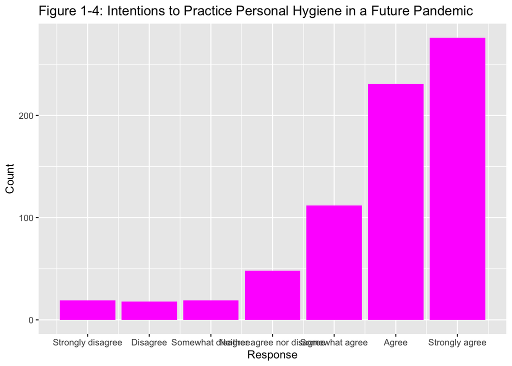

```r
future_sanitize_num <- likert_map[df_clean$future_sanitize]

ggplot(df_clean, aes(x = future_sanitize_num)) +
  geom_bar(fill = "magenta") +
  scale_x_continuous(breaks = 1:7, labels = names(likert_map)) +
  labs(title = "Figure 1-4: Intentions to Practice Personal Hygiene in a Future Pandemic", x = "Response", y = "Count")
```

*Description: Intentions to maintain hygiene (e.g., handwashing and sanitizing) were high, with the majority of participants selecting “Agree” or “Strongly Agree.” These results indicate that pandemic-era hygiene behaviors may persist into the future.*

## 3.4 Hospitality Establishment Visit Behaviors During the Pandemic

```r
he_vb <- data |>
    select(gel_estlmnt_visit_1:gel_estlmnt_visit_13)

he_vb <- he_vb |>
    mutate(across(where(is.labelled), as.numeric)) |>
    mutate(across(where(is.numeric), ~ replace_na(.x, 0)))

he_vb_longer <- he_vb |>
    pivot_longer(everything(), names_to = "names", values_to = "metric")

establishment_labels <- c("Restaurant", "Spa", "hair Salon", "Coffee Shop",
                         "Hotel/Motel", "Airbnb", "Others")

he_vb_longer <- he_vb_longer |>
    mutate(names = case_when(
        names == "gel_estlmnt_visit_1" ~ "Restaurant",
        names == "gel_estlmnt_visit_8" ~ "Spa",
        names == "gel_estlmnt_visit_9" ~ "hair Salon",
        names == "gel_estlmnt_visit_10" ~ "Coffee Shop",
        names == "gel_estlmnt_visit_11" ~ "Hotel/Motel",
        names == "gel_estlmnt_visit_12" ~ "Airbnb",
        names == "gel_estlmnt_visit_13" ~ "Others"
    )) |>
    mutate(names = fct_relevel(names, establishment_labels))
```

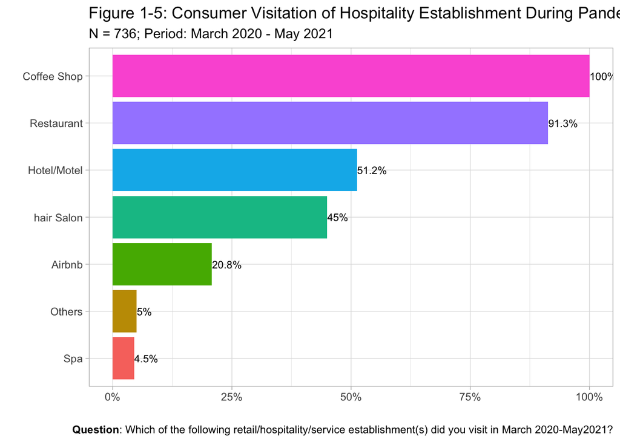

Figure 1: Hospitality Establishment Visit Behavior

```r
theme_set(theme_light())

N <- nrow(he_vb)
library(glue)
library(ggtext)

he_vb_longer |>
    group_by(names) |>
    summarise(percent = mean(metric)) |>
    mutate(names = fct_reorder(names, percent)) |>
    ggplot(aes(names, percent, fill = names)) +
    geom_col(show.legend = FALSE) +
    coord_flip() +
    scale_y_continuous(labels = scales::percent) +
    geom_text(aes(label = paste0(round(percent*100, 1),"%")),
              hjust = -0.01, size = 3) +
    labs(x = "", y = "",
         title = "Figure 1-5: Consumer Visitation of Hospitality Establishment During Pandemic",
         subtitle = glue("N = {N}; Period: March 2020 - May 2021"),
         caption = "**Question**: Which of the following retail/hospitality/service \nestablishment(s) did you visit in March 2020-May2021?"
    ) +
    theme(plot.caption = element_markdown())
```

*Descrition: This chart shows the types of hospitality businesses consumers visited during the peak of the pandemic. Coffee shops were among the most frequently visited, indicating that casual, routine visits remained common despite COVID-19 risks.*

## 3.5 Safety Perception at Hospitality Establishments

```r
he_safety <- data |>
    select(gel_estlmnt_safe_1:gel_estlmnt_safe_7)

he_safety <- he_safety |>
    mutate(across(where(is.labelled), haven::as_factor))

he_safety_longer <- he_safety |>
    pivot_longer(everything(), names_to = "names", values_to = "metric")

establishment_labels <- c("Restaurant", "Spa", "hair Salon", "Coffee Shop",
                         "Hotel/Motel", "Airbnb", "Others")

he_safety_longer <- he_safety_longer |>
    mutate(names = case_when(
        names == "gel_estlmnt_safe_1" ~ "Restaurant",
        names == "gel_estlmnt_safe_2" ~ "Spa",
        names == "gel_estlmnt_safe_3" ~ "hair Salon",
        names == "gel_estlmnt_safe_4" ~ "Coffee Shop",
        names == "gel_estlmnt_safe_5" ~ "Hotel/Motel",
        names == "gel_estlmnt_safe_6" ~ "Airbnb",
        names == "gel_estlmnt_safe_7" ~ "Others"
    )) |>
    mutate(names = fct_relevel(names, establishment_labels))
```

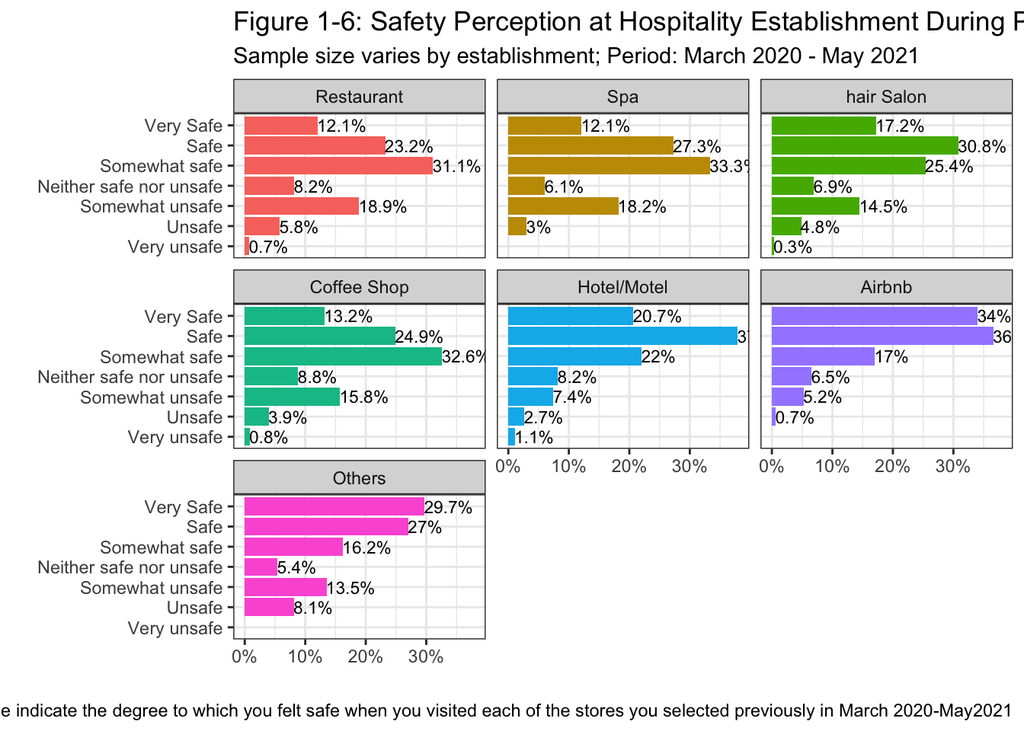

Figure 2: Hospitality Establishment Safety Perception

```r
theme_set(theme_bw())

he_safety_longer |>
    filter(!is.na(metric)) |>
    group_by(names) |>
    count(metric) |>
    mutate(percent = n/sum(n)) |>
    ggplot(aes(metric, percent, fill = names)) +
    geom_col(show.legend = FALSE) +
    coord_flip() +
    facet_wrap(~ names) +
    scale_y_continuous(labels = scales::percent) +
    geom_text(aes(label = paste0(round(percent*100, 1),"%")),
              hjust = 0.01, size = 3) +
    labs(x = "", y = "",
         title = "Figure 1-6: Safety Perception at Hospitality Establishment During Pandemic",
         subtitle = glue("Sample size varies by establishment; Period: March 2020 - May 2021"),
         caption = "**Question**: Please indicate the degree to which you felt safe \nwhen you visited each of the stores you selected \npreviously in March 2020-May2021"
    ) +
    theme(plot.caption = element_markdown())
```

*Descrption: This visualization captures how safe consumers felt while visiting different establishments. Coffee shops and restaurants had more mixed safety perceptions, highlighting the importance of visible preventative measures.*